# Tópico Complementar: Uma Introdução Rápida ao Pacote `lubridate`

Computação em Estatística II

Autor

Prof. Donald M. Pianto

Data de Publicação

16 de setembro de 2025

## 1. A Motivação: Por que `lubridate`?

Trabalhar com datas e horários em R pode ser complicado. Frequentemente, recebemos dados onde as datas são textos (`character`) e estão em formatos variados:

- `"2025-09-16"`
- `"September 16th, 2025"`
- `"16/09/25"`

Além disso, muitas vezes os componentes de data (ano, mês, dia) vêm em colunas separadas. O pacote `lubridate`, que faz parte do `tidyverse`, foi criado para tornar essas tarefas de manipulação de datas incrivelmente simples e intuitivas.

```r
library(tidyverse)
# O lubridate já é carregado com o tidyverse, mas é uma boa prática ser explícito
library(lubridate)
library(dados) # Para o dataset voos
```

## 2. O Essencial: Criando Datas a partir de Strings

A tarefa mais comum é converter uma string em um objeto de data. O `lubridate` tem funções auxiliares “mágicas” para isso. O nome da função corresponde à ordem em que os componentes de ano (`y`), mês (`m`) e dia (`d`) aparecem na sua string.

```r
# Formato Ano-Mês-Dia
ymd("2025-09-16")
```

```
[1] "2025-09-16"
```

```r
# Formato Mês-Dia-Ano (funciona com nomes de meses!)
mdy("September 16th, 2025")
```

```
[1] "2025-09-16"
```

```r
# Formato Dia-Mês-Ano
dmy("16-Set-2025")
```

```
[1] "2025-09-16"
```

Note que o `lubridate` é inteligente o suficiente para lidar com diferentes separadores (`-`, `/`, espaço, etc.). O mesmo padrão se aplica a data-horas, adicionando `_hms` ao final da função (ex: `ymd_hms()`).

## 3. Criando Datas a partir de Componentes Individuais

Outro cenário comum, como no dataset `voos`, é ter o ano, o mês e o dia em colunas separadas. A função `make_date()` resolve isso de forma elegante.

```r
# Visualizando as colunas originais
voos |>
  select(ano, mes, dia) |>
  head()
```

```
# A tibble: 6 × 3
    ano   mes   dia
  <int> <int> <int>
1  2013     1     1
2  2013     1     1
3  2013     1     1
4  2013     1     1
5  2013     1     1
6  2013     1     1
```

```r
# Combinando-as para criar uma nova coluna de data
voos |>
  select(ano, mes, dia) |>
  mutate(data_completa = make_date(ano, mes, dia)) |>
  head()
```

```
# A tibble: 6 × 4
    ano   mes   dia data_completa
  <int> <int> <int> <date>
1  2013     1     1 2013-01-01
2  2013     1     1 2013-01-01
3  2013     1     1 2013-01-01
4  2013     1     1 2013-01-01
5  2013     1     1 2013-01-01
6  2013     1     1 2013-01-01
```

O análogo para data-horas, se você também tiver colunas para hora, minuto e segundo, é a função `make_datetime()`.

## 4. Primeira Aplicação: Extraindo Componentes

Uma vez que temos um objeto de data, podemos facilmente extrair seus componentes para análise. `lubridate` oferece funções intuitivas para isso: `year()`, `month()`, `mday()` (dia do mês) e `wday()` (dia da semana).

Isso é extremamente útil para agrupar dados e encontrar padrões, como a quantidade de voos por dia da semana.

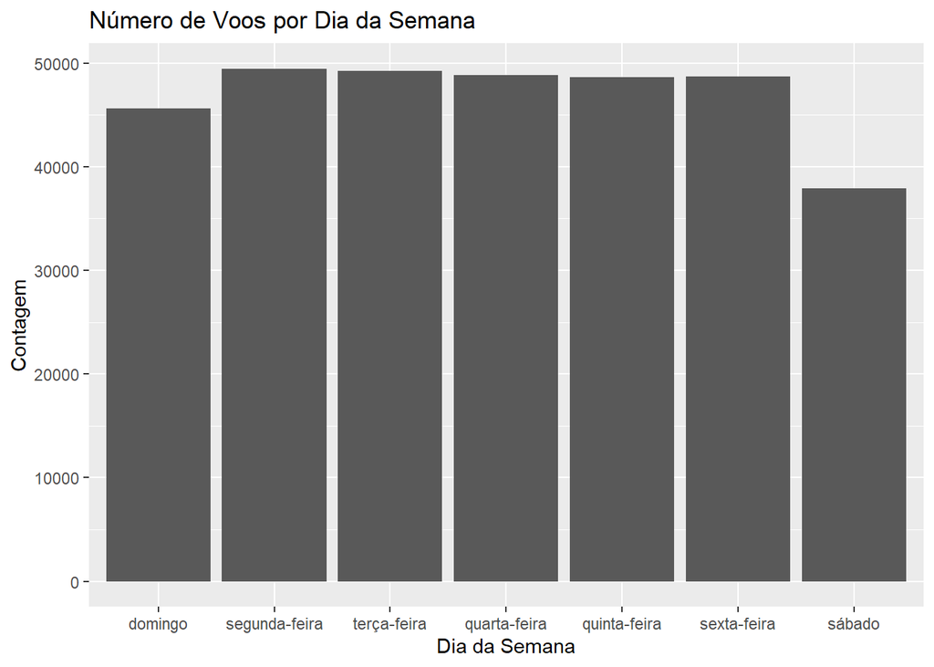

```r
# 1. Primeiro, criamos a coluna de data-hora da partida
voos_dt <- voos |>
  filter(!is.na(horario_saida)) |>
  mutate(
    saida_dt = make_datetime(ano, mes, dia, horario_saida %/% 100, horario_saida %% 100)
  )

# 2. Agora, extraímos o dia da semana e plotamos
voos_dt |>
  mutate(dia_semana = wday(saida_dt, label = TRUE, abbr = FALSE)) |>
  ggplot(aes(x = dia_semana)) +
  geom_bar() +
  labs(
    title = "Número de Voos por Dia da Semana",
    x = "Dia da Semana",
    y = "Contagem"
  )
```

## 5. Conclusão e Próximos Passos

Hoje vimos como o `lubridate` resolve os dois problemas mais comuns com datas:

1. **Ler (parse)** datas de textos em diferentes formatos (`ymd`, `mdy`, `dmy`).
2. **Criar** datas a partir de colunas de componentes (`make_date`).

Também vimos como **extrair** informações úteis de objetos de data para criar visualizações e sumários.

O `lubridate` tem muito mais poder, incluindo ferramentas para fazer cálculos com datas (durações e períodos) e para lidar com a complexidade de fusos horários. Exploraremos esses tópicos avançados em uma aula futura.